# Who will win Next IPL Season

Sourabh Gupta

March 22, 2019

##### **To: All cricket fans**

##### **From: Sourabh Gupta**

##### **Date: March 22, 2019**

##### **RE: What all factors affect a win and Which team has highest chances of winning**

**Context**: Cricket is a bat-and-ball game played between two teams of eleven players each on a cricket field, at the centre of which is a rectangular 20-metre (22-yard) pitch with a target at each end called the wicket (a set of three wooden stumps upon which two bails sit). Each phase of play is called an innings, during which one team bats, attempting to score as many runs as possible, whilst their opponents bowl and field, attempting to minimise the number of runs scored. When each innings ends, the teams usually swap roles for the next innings (i.e. the team that previously batted will bowl/field, and vice versa). The teams each bat for one or two innings, depending on the type of match. The winning team is the one that scores the most runs, including any extras gained (except when the result is not a win/loss result).

**Data available**: All Indian Premier League Cricket matches between 2008 and 2017.

This is the ball by ball data of all the IPL cricket matches till season 10.

The dataset contains 2 files: deliveries.csv and matches.csv.

matches.csv contains details related to the match such as location, contesting teams, umpires, results, etc.

deliveries.csv is the ball-by-ball data of all the IPL matches including data of the batting team, batsman, bowler, non-striker, runs scored, etc.

**Factors affect the result**:

I think the following points support the conclusions that I have drawn:

#### **Factor 1**: *Top scoring batsman increases chances of winning*

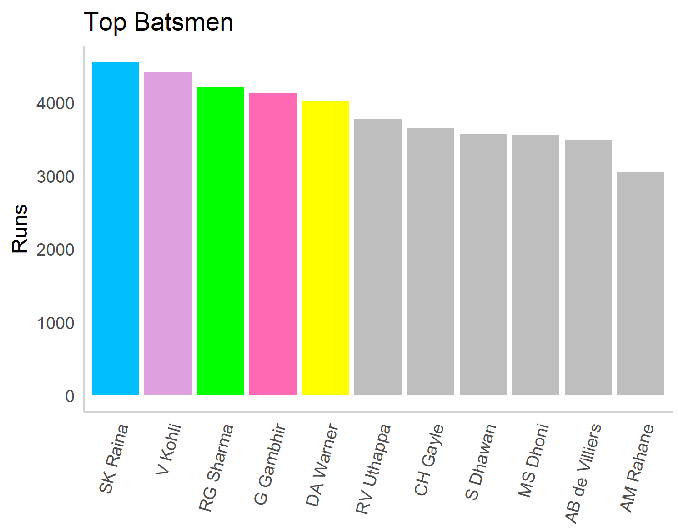

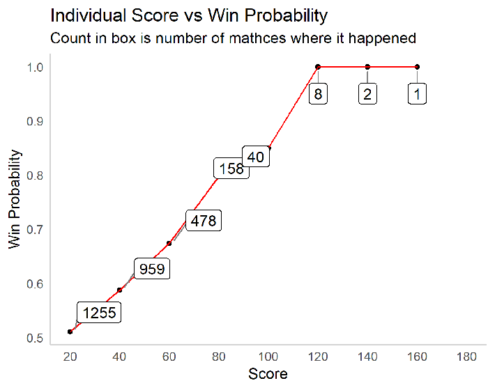

We have included probability results to confirm if scoring high runs actually increases the probabilities of winning

#### **Factor 2**: *High wicket taking bowler increases chances of winning*

Key points:

- Taking wickets help the team to stop other team to make good score
- Except SL Malings, every other bowler has almost same track record
- Taking wickets in early stage of game increases the probability of winning very much
  - SL Malings and Harbajan Singh both have great records of taking most wickets
- All Top 5 players are spinners or medium pacers:
  - One thing is quite interesting here is, in IPL pacers do not increases the changes of winning on average
  - That is why SL Malings has highest budget among bowlers

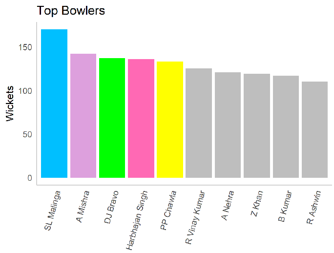

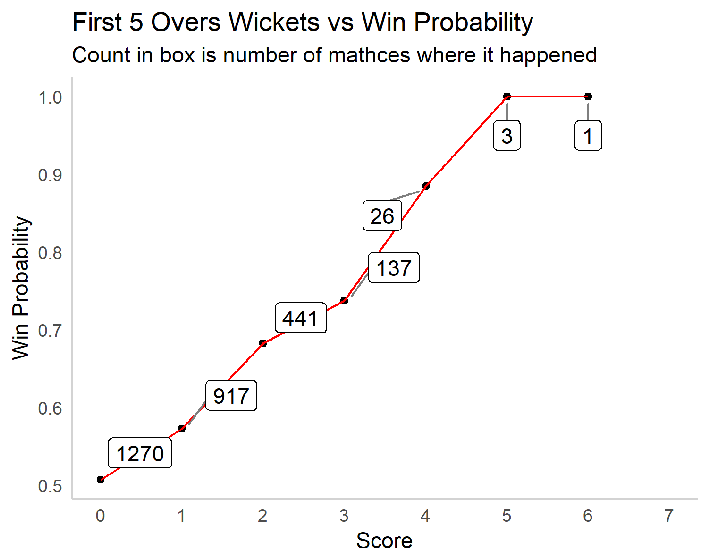

#### **Conclusion**: *Mumbai Indians have high chances of winning this year, IPL-2019*

Mumbai Indians has lifted the trophy maximum number of times 3 out of 10.

Their coach cum mentor - Sachin Tendulkar is the biggest player of the cricket history.

Based on the above two findings, we should review the players who are changing squads and their impact on the winning of match and league

We would be happy to review this analysis in further detail, with you, in case you have any further questions.

#### **PS**: What ever analysis be made, the success rate of Prediction is very minimal. So Keep Calm and watch the match. Anything could be a turning point in the match.

Best,

Sourabh Gupta,

**guptasourabh@seattleu.edu**

**(425)-633-6988**